# Labour Market Polarisation Across Indian Districts — Distributional Analysis

## Overview

This notebook tests the core research question: is there evidence of labour market polarisation — declining middle-skill employment shares — across Indian districts between 2017-18 and 2023-24? Using the district-level panel constructed in `02_aggregate.Rmd`, we examine national skill share trends, the district-level distribution of skill shares and how it shifts over time, and whether the pattern is consistent with the middle-skill hollowing predicted by the routine-biased technological change framework.

All analysis uses the balanced panel — districts present in all seven rounds — to ensure temporal comparisons are made on consistent geographic units. A minimum cell size threshold of 25 raw observations per district-round-sector cell is applied throughout to exclude unreliable estimates. Urban and rural sectors are analysed separately given their structurally different skill distributions and the NCO 121 coding inconsistency that affects cross-round comparability of the three-way classification in rural areas.

Libraries used in this notebook: `tidyverse` for data manipulation and `ggplot2` for all visualisations, `patchwork` for combining multiple panels, and `scales` for axis formatting.

```r
library(tidyverse)
library(patchwork)
library(scales)
```

## Load Panels and Apply Filters

```r
skill <- readRDS("~/Desktop/UZH/Pre-Doc/Prep/BRICS-Trade-Labour-Portfolio/03_labour_polarisation_india/data/plfs_skill_panel.rds")

agri <- readRDS("~/Desktop/UZH/Pre-Doc/Prep/BRICS-Trade-Labour-Portfolio/03_labour_polarisation_india/data/plfs_agri_panel.rds")

# Minimum cell size threshold
MIN_N <- 25

# Apply filters: balanced panel + minimum cell size
skill_bal <- skill |>
  filter(balanced_panel == TRUE, emp_n >= MIN_N)

agri_bal <- agri |>
  filter(balanced_panel == TRUE, emp_n >= MIN_N)

# Report filtering impact
cat("=== Skill panel ===\n")
```

```
## === Skill panel ===
```

```r
cat("Total rows:          ", nrow(skill), "\n")
```

```
## Total rows:           70728
```

```r
cat("After balanced filter:", nrow(filter(skill, balanced_panel)), "\n")
```

```
## After balanced filter: 62756
```

```r
cat("After cell size filter:", nrow(skill_bal), "\n")
```

```
## After cell size filter: 22633
```

```r
cat("\n=== Agri panel ===\n")
```

```
##
## === Agri panel ===
```

```r
cat("Total rows:          ", nrow(agri), "\n")
```

```
## Total rows:           50091
```

```r
cat("After balanced filter:", nrow(filter(agri, balanced_panel)), "\n")
```

```
## After balanced filter: 44250
```

```r
cat("After cell size filter:", nrow(agri_bal), "\n")
```

```
## After cell size filter: 21522
```

```r
cat("\n=== Districts retained by sector (skill panel, overall sex) ===\n")
```

```
##
## === Districts retained by sector (skill panel, overall sex) ===
```

```r
skill_bal |>
  filter(sex == "all") |>
  distinct(state_district, file_sector) |>
  count(file_sector)
```

| file_sector | n |
| --- | --- |
| rural | 486 |
| urban | 628 |

After applying both filters, 486 rural and 628 urban districts are retained in the skill panel. The cell size filter is relatively aggressive — removing 64% of balanced panel rows — reflecting the PLFS district-level sample design, which was not optimised for small-area estimation. Smaller districts and thinner skill group cells are excluded. These filters are applied throughout the district-level analysis. For national trend estimates, we use the full balanced panel without the cell size filter, since national aggregation across all districts is not sensitive to individual small-cell instability.

## National Skill Share Trends

We begin with the aggregate picture: how have employment shares across skill groups evolved nationally between 2017-18 and 2023-24? We compute population-weighted national shares by summing weighted employment counts across all balanced-panel districts and computing shares from those totals. Urban and rural are shown separately.

```r
# National trends: use full balanced panel (no cell size filter)
# Weight by emp_wtd so larger districts contribute proportionally
national_skill <- skill |>
  filter(balanced_panel == TRUE, sex == "all") |>
  group_by(year, file_sector, skill_group) |>
  summarise(emp_wtd_total = sum(emp_wtd), .groups = "drop") |>
  group_by(year, file_sector) |>
  mutate(national_share = emp_wtd_total / sum(emp_wtd_total)) |>
  ungroup()

# Print the table
cat("=== National skill shares by round and sector ===\n")
```

```
## === National skill shares by round and sector ===
```

```r
national_skill |>
  select(year, file_sector, skill_group, national_share) |>
  mutate(national_share = round(national_share * 100, 1)) |>
  pivot_wider(names_from = skill_group, values_from = national_share) |>
  arrange(file_sector, year) |>
  print(n = 14)
```

```
## # A tibble: 14 × 5
##     year file_sector  high   low middle
##    <int> <chr>       <dbl> <dbl>  <dbl>
##  1  2018 rural        41.7  14.6   43.6
##  2  2019 rural        43.2  14.6   42.2
##  3  2020 rural        45.9  14.9   39.2
##  4  2021 rural        45.4  15.6   39.1
##  5  2022 rural        37.8  14.4   47.8
##  6  2023 rural        27.3  14.7   58
##  7  2024 rural        23.6  15.1   61.2
##  8  2018 urban        15.6  62.3   22.1
##  9  2019 urban        18.1  60.8   21.1
## 10  2020 urban        18.2  62.2   19.6
## 11  2021 urban        17.2  63     19.8
## 12  2022 urban        14.8  62.5   22.7
## 13  2023 urban         8.5  61.7   29.8
## 14  2024 urban         7.6  62.8   29.6
```

Three patterns are immediately visible in the national trend table.

First, the low-skill share is remarkably stable throughout — rural fluctuates between 14.4% and 15.6%, urban between 60.8% and 63.0% across all seven rounds. This stability is expected since low-skill workers (NCO groups 6 and 9) were unaffected by the NCO 121 coding revision and provides a useful internal consistency check.

Second, the rural high-skill share rises from 41.7% in 2018 to 45.9% in 2020 and then collapses to 23.6% by 2024, while middle skill moves in the exact opposite direction (43.6% → 61.2%). The 2021-to-2022 break — high dropping 7.6 percentage points and middle rising 8.7 points in a single year — is the NCO 121 coding revision, not an economic phenomenon.

Third, the urban pattern is similar but less extreme: high skill rises modestly to 18.2% by 2020, then falls to 7.6% by 2024, while middle rises from 22.1% to 29.6%. The urban break between 2021 and 2022 is smaller than rural (high drops 2.4pp) but still present.

The honest conclusion from the three-way classification is that we cannot cleanly identify polarisation from these national trends because the coding break contaminates the high-skill and middle-skill series from 2021-22 onwards. The reliable signal is the stability of low-skill shares. We now visualise these trends explicitly, marking the coding break, and then shift to the agri/non-agri panel as the primary analytical series.

## Visualising National Trends

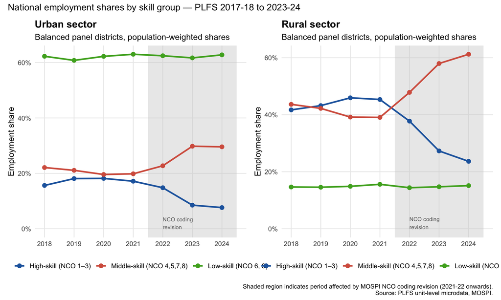

```r
# Skill group labels for clean display
skill_labels <- c(high = "High-skill (NCO 1–3)",
                  low  = "Low-skill (NCO 6, 9)",
                  middle = "Middle-skill (NCO 4,5,7,8)")

skill_colours <- c(high   = "#2166ac",
                   middle = "#d6604d",
                   low    = "#4dac26")

# Separate urban and rural plots
plot_national <- function(sector_name, title_text) {
  national_skill |>
    filter(file_sector == sector_name) |>
    mutate(skill_group = factor(skill_group,
                                levels = c("high", "middle", "low"))) |>
    ggplot(aes(x = year, y = national_share * 100,
               colour = skill_group, group = skill_group)) +
    # Shade the post-break period
    annotate("rect", xmin = 2021.5, xmax = 2024.5,
             ymin = -Inf, ymax = Inf,
             fill = "grey80", alpha = 0.4) +
    annotate("text", x = 2022, y = 2,
             label = "NCO coding\nrevision", size = 2.8,
             colour = "grey40", hjust = 0) +
    geom_line(linewidth = 1.1) +
    geom_point(size = 2.5) +
    scale_colour_manual(values = skill_colours,
                        labels = skill_labels,
                        name = NULL) +
    scale_x_continuous(breaks = 2018:2024) +
    scale_y_continuous(labels = label_number(suffix = "%"),
                       limits = c(0, NA)) +
    labs(title    = title_text,
         subtitle = "Balanced panel districts, population-weighted shares",
         x = NULL, y = "Employment share") +
    theme_minimal(base_size = 12) +
    theme(legend.position  = "bottom",
          panel.grid.minor = element_blank(),
          plot.title       = element_text(face = "bold"))
}

p_urban <- plot_national("urban", "Urban sector")
p_rural <- plot_national("rural", "Rural sector")

(p_urban | p_rural) +
  plot_annotation(
    title   = "National employment shares by skill group — PLFS 2017-18 to 2023-24",
    caption = "Shaded region indicates period affected by MOSPI NCO coding revision (2021-22 onwards).\nSource: PLFS unit-level microdata, MOSPI."
  )
```

The plot makes the analytical situation unambiguous. In the urban panel, the low-skill share (green) is flat throughout at 61-63% — a stable dominant category. Middle skill rises modestly from 22% to 30% entirely within the shaded post-coding-revision period, while high skill declines correspondingly. In the rural panel, the crossing of high and middle skill lines occurs precisely at the coding revision boundary. The pre-revision period (2018-2021) shows high skill around 42-46% and middle around 39-44%, while post-revision middle dominates at 48-61%. The low-skill rural line is flat at 14-15% throughout, confirming it as the most reliably measured category.

The three-way classification cannot support claims about polarisation in this data — the apparent middle-skill rise is driven primarily by the coding revision reassigning high-skill workers to middle-skill categories, not by genuine labour market restructuring. We now examine the agri/non-agri series, which is immune to this problem.

## Agricultural vs Non-Agricultural Structural Transition

The agri/non-agri binary classification uses NCO groups 6 and 9 — the same groups that form the stable low-skill category above — and is therefore unaffected by the NCO 121 coding revision. A rising non-agricultural share represents structural transformation: workers moving out of agricultural occupations into non-farm employment.

```r
# National agri/non-agri trends
national_agri <- agri |>
  filter(balanced_panel == TRUE, sex == "all") |>
  group_by(year, file_sector, agri_nonagri) |>
  summarise(emp_wtd_total = sum(emp_wtd), .groups = "drop") |>
  group_by(year, file_sector) |>
  mutate(national_share = emp_wtd_total / sum(emp_wtd_total)) |>
  ungroup()

# Print table
cat("=== Non-agricultural employment share by round and sector ===\n")
```

```
## === Non-agricultural employment share by round and sector ===
```

```r
national_agri |>
  filter(agri_nonagri == "non_agricultural") |>
  select(year, file_sector, national_share) |>
  mutate(national_share = round(national_share * 100, 1)) |>
  pivot_wider(names_from = file_sector, values_from = national_share) |>
  arrange(year) |>
  print()
```

```
## # A tibble: 7 × 3
##    year rural urban
##   <int> <dbl> <dbl>
## 1  2018  85.4  37.7
## 2  2019  85.4  39.2
## 3  2020  85.1  37.8
## 4  2021  84.4  37
## 5  2022  85.6  37.5
## 6  2023  85.3  38.3
## 7  2024  84.9  37.2
```

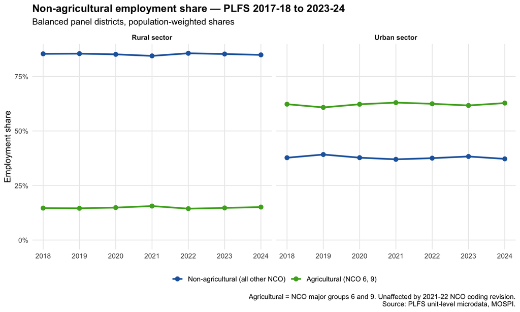

```r
# Plot
agri_colours <- c(agricultural     = "#4dac26",
                  non_agricultural = "#2166ac")
agri_labels  <- c(agricultural     = "Agricultural (NCO 6, 9)",
                  non_agricultural = "Non-agricultural (all other NCO)")

national_agri |>
  mutate(agri_nonagri = factor(agri_nonagri,
                               levels = c("non_agricultural",
                                          "agricultural"))) |>
  ggplot(aes(x = year, y = national_share * 100,
             colour = agri_nonagri, group = agri_nonagri)) +
  geom_line(linewidth = 1.1) +
  geom_point(size = 2.5) +
  scale_colour_manual(values = agri_colours,
                      labels = agri_labels,
                      name   = NULL) +
  scale_x_continuous(breaks = 2018:2024) +
  scale_y_continuous(labels = label_number(suffix = "%"),
                     limits = c(0, NA)) +
  facet_wrap(~file_sector,
             labeller = labeller(file_sector = c(urban = "Urban sector",
                                                 rural = "Rural sector"))) +
  labs(title    = "Non-agricultural employment share — PLFS 2017-18 to 2023-24",
       subtitle = "Balanced panel districts, population-weighted shares",
       caption  = "Agricultural = NCO major groups 6 and 9. Unaffected by 2021-22 NCO coding revision.\nSource: PLFS unit-level microdata, MOSPI.",
       x = NULL, y = "Employment share") +
  theme_minimal(base_size = 12) +
  theme(legend.position  = "bottom",
        panel.grid.minor = element_blank(),
        plot.title       = element_text(face = "bold"),
        strip.text       = element_text(face = "bold"))
```

The agri/non-agri trends reveal a finding that is honest but analytically challenging: both the rural non-agricultural share (~84-85%) and the urban non-agricultural share (~37-39%) are essentially flat across all seven rounds. There is no detectable trend in either direction.

For rural areas, a non-agricultural share of 85% is implausibly high — it would imply that the vast majority of rural employed workers are in non-farm occupations, contradicting all available evidence on Indian rural employment structure. The high non-agricultural share is a direct consequence of the NCO coding issues identified in `01_clean.Rmd`: a large fraction of rural workers are coded as managers (NCO 121, 35-40% of rural employed in early rounds) or service workers (NCO 522, rising to 35% in later rounds) rather than in agricultural categories. These workers are likely smallholder farmers, agricultural traders, or rural self-employed individuals whose occupations were imprecisely coded by PLFS enumerators.

For urban areas, the 62-63% agricultural share is driven by the persistent NCO 611 coding that we noted in the cleaning notebook — a large proportion of urban workers classified as market gardeners or crop growers, which is also implausible at that scale.

The combined picture is clear: PLFS NCO coding quality in this period is insufficient to support credible national-level claims about either skill polarisation or agricultural structural transformation. Both the three-way classification and the binary classification are affected, albeit through different channels. The low-skill category (NCO 6+9) is internally consistent and stable, but its level is unreliable as a measure of actual agricultural employment.

The analytical pivot is therefore to cross-sectional variation across districts. Even if national levels are mis-measured due to coding issues, the distribution of skill shares across districts may contain genuine geographic signal — districts with systematically different NCO coding patterns are less likely to drive cross-sectional variation than time-series revisions. The remainder of this notebook focuses on district heterogeneity: which districts show higher or lower non-agricultural or skill shares, how that distribution varies, and how it correlates with trade exposure in Notebook 6.

## District-Level Distribution of Non-Agricultural Employment

We examine the cross-sectional distribution of the non-agricultural employment share across districts for each round. Despite unreliable national levels, cross-district variation may reflect genuine geographic differences in economic structure. We use the balanced, cell-size-filtered agri panel and focus on the non-agricultural share as the more stable measure.

```r
# Non-agricultural share at district level
# One observation per district per round per sector
nonagri_dist <- agri_bal |>
  filter(sex == "all", agri_nonagri == "non_agricultural") |>
  mutate(year_label = paste0(year - 1, "-", substr(year, 3, 4)))

# Summary statistics of district non-agri share by round and sector
cat("=== District-level non-agricultural share: summary ===\n")
```

```
## === District-level non-agricultural share: summary ===
```

```r
nonagri_dist |>
  group_by(year, file_sector) |>
  summarise(
    n_districts = n(),
    mean   = round(mean(agri_share) * 100, 1),
    sd     = round(sd(agri_share) * 100, 1),
    p25    = round(quantile(agri_share, 0.25) * 100, 1),
    median = round(median(agri_share) * 100, 1),
    p75    = round(quantile(agri_share, 0.75) * 100, 1),
    .groups = "drop"
  ) |>
  arrange(file_sector, year) |>
  print(n = 14)
```

```
## # A tibble: 14 × 8
##     year file_sector n_districts  mean    sd   p25 median   p75
##    <int> <chr>             <int> <dbl> <dbl> <dbl>  <dbl> <dbl>
##  1  2018 rural               288  85.5  12.1  79.6   88.7  94.9
##  2  2019 rural               401  83.7  12.7  77.1   85.9  93.5
##  3  2020 rural               392  82.9  12.8  75.3   85    92.8
##  4  2021 rural               417  82.5  13.7  75.2   84.6  93.1
##  5  2022 rural               412  83.6  13.5  75.9   87.3  93.7
##  6  2023 rural               421  82.9  13.6  75.5   86.3  92.9
##  7  2024 rural               412  81.9  14.6  73.4   85.6  92.8
##  8  2018 urban               418  44.4  20.7  27.8   42.2  58.4
##  9  2019 urban               414  47    20.4  31.9   44.9  60.4
## 10  2020 urban               429  46.2  21.3  29.5   43.8  60.2
## 11  2021 urban               441  45.1  20.9  28.1   42.1  59.1
## 12  2022 urban               441  44.9  20.2  28.4   42.4  58.3
## 13  2023 urban               464  43.9  20.4  27.5   39.7  58
## 14  2024 urban               463  43.7  20.1  28.5   41    56.7
```

Second, the rural mean non-agricultural share shows a mild declining trend (85.5% in 2018 to 81.9% in 2024) while rural standard deviation widens slightly (12.1 to 14.6). The declining mean is consistent with the NCO 121 revision reducing the share of workers incorrectly coded as high-skill non-agricultural, but the widening standard deviation suggests the cross-district distribution is also spreading — some districts becoming more divergent from the national pattern over time. Urban means and medians are essentially flat throughout.

The number of districts per round varies slightly due to the cell size filter — more districts are retained in rounds with larger samples. The 2017-18 rural figure (288 districts) is notably lower than subsequent rounds, consistent with the smaller 2017-18 rural sample documented in earlier notebooks.

## District Distribution — Kernel Density

Overlaid kernel density estimates of the district non-agricultural employment share for each round show whether the cross-district distribution is shifting, widening, or stable over time.

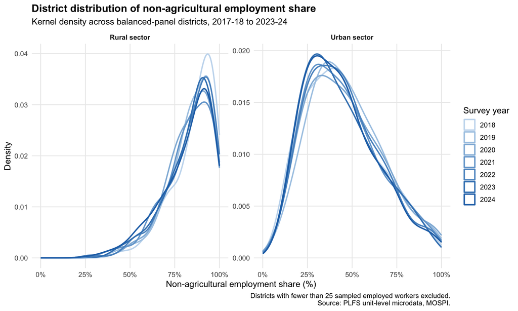

```r
# Kernel density of district non-agri share by round
sector_labels <- c(rural = "Rural sector", urban = "Urban sector")

# Colour palette: sequential from light to dark blue across years
year_colours <- colorRampPalette(c("#c6dbef", "#2171b5"))(7)
names(year_colours) <- as.character(2018:2024)

nonagri_dist |>
  mutate(year_chr = as.character(year)) |>
  ggplot(aes(x = agri_share * 100,
             colour = year_chr,
             group  = year_chr)) +
  geom_density(linewidth = 0.9, adjust = 1.2) +
  scale_colour_manual(values = year_colours,
                      name   = "Survey year") +
  scale_x_continuous(labels = label_number(suffix = "%"),
                     limits = c(0, 100)) +
  facet_wrap(~file_sector,
             scales   = "free_y",
             labeller = labeller(file_sector = sector_labels)) +
  labs(title    = "District distribution of non-agricultural employment share",
       subtitle = "Kernel density across balanced-panel districts, 2017-18 to 2023-24",
       caption  = "Districts with fewer than 25 sampled employed workers excluded.\nSource: PLFS unit-level microdata, MOSPI.",
       x = "Non-agricultural employment share (%)",
       y = "Density") +
  theme_minimal(base_size = 12) +
  theme(legend.position  = "right",
        panel.grid.minor = element_blank(),
        plot.title       = element_text(face = "bold"),
        strip.text       = element_text(face = "bold"))
```

The kernel density plots confirm the district distribution is remarkably stable across all seven rounds in both sectors. In the rural panel, the distribution is concentrated between 75-100% non-agricultural with a peak near 90%, and the seven overlapping density curves are nearly indistinguishable — no discernible shift left or right over the period. In the urban panel, the distribution peaks around 25-35% non-agricultural and extends to a long right tail, again with minimal movement across rounds. The 2018 rural curve (lightest blue) shows a slightly tighter, higher peak than later rounds, consistent with the marginally higher mean in that year, but this difference is small.

The cross-sectional spread in urban districts — a range from near-zero to 100% — reflects genuine geographic diversity in Indian urban economic structure that persists throughout the panel. This cross-sectional variation is the primary signal available for analysis. The absence of distributional shift across rounds, combined with the flat national means, confirms that no detectable aggregate structural transformation occurred within this seven-year window that is separable from NCO coding artefacts.

## COVID-19 Shock Assessment

```r
# Compare district non-agri shares across three periods:
# Pre-COVID: 2019-20 (year=2020)
# COVID:     2020-21 (year=2021)
# Recovery:  2021-22 (year=2022)

covid_compare <- nonagri_dist |>
  filter(year %in% c(2020, 2021, 2022)) |>
  mutate(period = case_when(
    year == 2020 ~ "Pre-COVID\n(2019-20)",
    year == 2021 ~ "COVID year\n(2020-21)",
    year == 2022 ~ "Recovery\n(2021-22)"
  ),
  period = factor(period,
                  levels = c("Pre-COVID\n(2019-20)",
                             "COVID year\n(2020-21)",
                             "Recovery\n(2021-22)")))

# Summary statistics for each period
cat("=== Non-agricultural share: pre-COVID, COVID, and recovery ===\n")
```

```
## === Non-agricultural share: pre-COVID, COVID, and recovery ===
```

```r
covid_compare |>
  group_by(file_sector, period) |>
  summarise(
    n      = n(),
    mean   = round(mean(agri_share) * 100, 1),
    median = round(median(agri_share) * 100, 1),
    sd     = round(sd(agri_share) * 100, 1),
    .groups = "drop"
  ) |>
  print()
```

```
## # A tibble: 6 × 6
##   file_sector period                      n  mean median    sd
##   <chr>       <fct>                   <int> <dbl>  <dbl> <dbl>
## 1 rural       "Pre-COVID\n(2019-20)"    392  82.9   85    12.8
## 2 rural       "COVID year\n(2020-21)"   417  82.5   84.6  13.7
## 3 rural       "Recovery\n(2021-22)"     412  83.6   87.3  13.5
## 4 urban       "Pre-COVID\n(2019-20)"    429  46.2   43.8  21.3
## 5 urban       "COVID year\n(2020-21)"   441  45.1   42.1  20.9
## 6 urban       "Recovery\n(2021-22)"     441  44.9   42.4  20.2
```

```r
# Paired change: pre-COVID vs COVID year for each district
covid_change <- nonagri_dist |>
  filter(year %in% c(2020, 2021)) |>
  select(state_district, file_sector, year, agri_share) |>
  pivot_wider(names_from = year,
              values_from = agri_share,
              names_prefix = "yr_") |>
  filter(!is.na(yr_2020), !is.na(yr_2021)) |>
  mutate(covid_change = (yr_2021 - yr_2020) * 100)

cat("\n=== District-level change in non-agri share: 2019-20 to 2020-21 ===\n")
```

```
##
## === District-level change in non-agri share: 2019-20 to 2020-21 ===
```

```r
covid_change |>
  group_by(file_sector) |>
  summarise(
    n_districts     = n(),
    mean_change     = round(mean(covid_change), 2),
    sd_change       = round(sd(covid_change), 2),
    pct_declined    = round(mean(covid_change < 0) * 100, 1),
    pct_increased   = round(mean(covid_change > 0) * 100, 1),
    .groups = "drop"
  ) |>
  print()
```

```
## # A tibble: 2 × 6
##   file_sector n_districts mean_change sd_change pct_declined pct_increased
##   <chr>             <int>       <dbl>     <dbl>        <dbl>         <dbl>
## 1 rural               349       -0.11      13.7         49.9          48.1
## 2 urban               370       -1.24      13.5         54.3          45.7
```

The COVID shock analysis produces one of the more analytically interesting findings in this notebook. At the aggregate level, the pandemic produced essentially no detectable shift in the non-agricultural employment share — rural mean fell by just 0.4 percentage points and urban by 1.1 points from pre-COVID to the COVID year, both well within sampling variation. The recovery year shows rural mean rebounding above pre-COVID levels (83.6% vs 82.9%) and urban remaining stable.

At the district level, the picture is striking: 49.9% of rural districts and 54.3% of urban districts showed a decline in non-agricultural share during the COVID year, while the remainder showed an increase. The mean district-level change is effectively zero for rural (-0.11pp) and small for urban (-1.24pp), but the standard deviation of district-level changes is enormous — 13.7pp for rural and 13.5pp for urban. This means individual districts experienced swings of ±13 percentage points in either direction, but these swings were largely offsetting at the aggregate level.

This pattern is consistent with PLFS capturing the labour market reality of COVID-19 in India: the pandemic produced severe but heterogeneous local disruptions — some districts lost large shares of non-agricultural employment while others gained — without a systematic aggregate sectoral shift. Workers who lost non-agricultural work appear to have largely returned to previous activity patterns within the PLFS reference periods, rather than permanently shifting into agriculture. The absence of a permanent post-COVID structural break is confirmed by the recovery year means returning to pre-COVID levels.

## Summary

This notebook has examined the core polarisation research question using the PLFS district panel. The principal findings are:

**On the three-way skill classification:** The national trend analysis confirms that the NCO 121 coding revision between 2020-21 and 2021-22 makes cross-round comparison of the three-way skill classification unreliable. The high- and middle-skill series show a large discontinuity at the revision boundary. The low-skill share (NCO groups 6 and 9) is the only component of the three-way classification that is stable and internally consistent throughout the panel.

**On the COVID shock:** No aggregate structural break is detectable. District-level changes are large in absolute terms but statistically offsetting, consistent with a heterogeneous but largely transient pandemic disruption.

**Implication for subsequent notebooks:** Notebooks 4 and 5 (gender decomposition, urban-rural split) examine whether the cross-sectional variation is patterned by gender or geographic type. Notebook 6 tests whether districts with greater trade exposure, as measured by Project 6’s spatial proxies, systematically differ in their non-agricultural employment structure — the primary causal hypothesis of the portfolio.

**Proceed to `04_gender.Rmd`.**